# Hierarchical Homework

```r
# hierarchical clustering using a manhattan distance matrix and wards distance
# for forming clusters
hier_clust_manhattan_ward <- hclust(dist_matrix_manhattan, method = 'ward.D')
```

The dendogram shows a strong possibility of 2, maybe 5 clusters

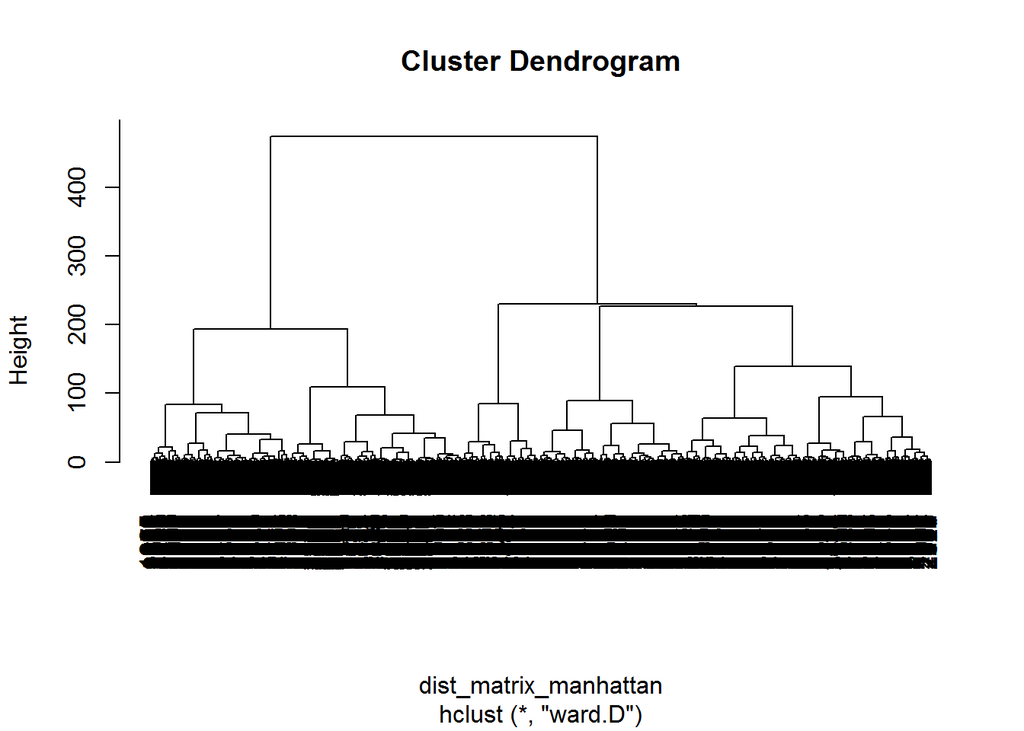

```r
plot(hier_clust_manhattan_ward)
```

```r
# Hard to tell what is going on
hier_clust_manhattan_average <- hclust(dist_matrix_manhattan, method = 'average')
# It appears 3 clusters does appear to be a correct number of clusters
```

again, The average method does not produce very interpretable clusters in the dendogram

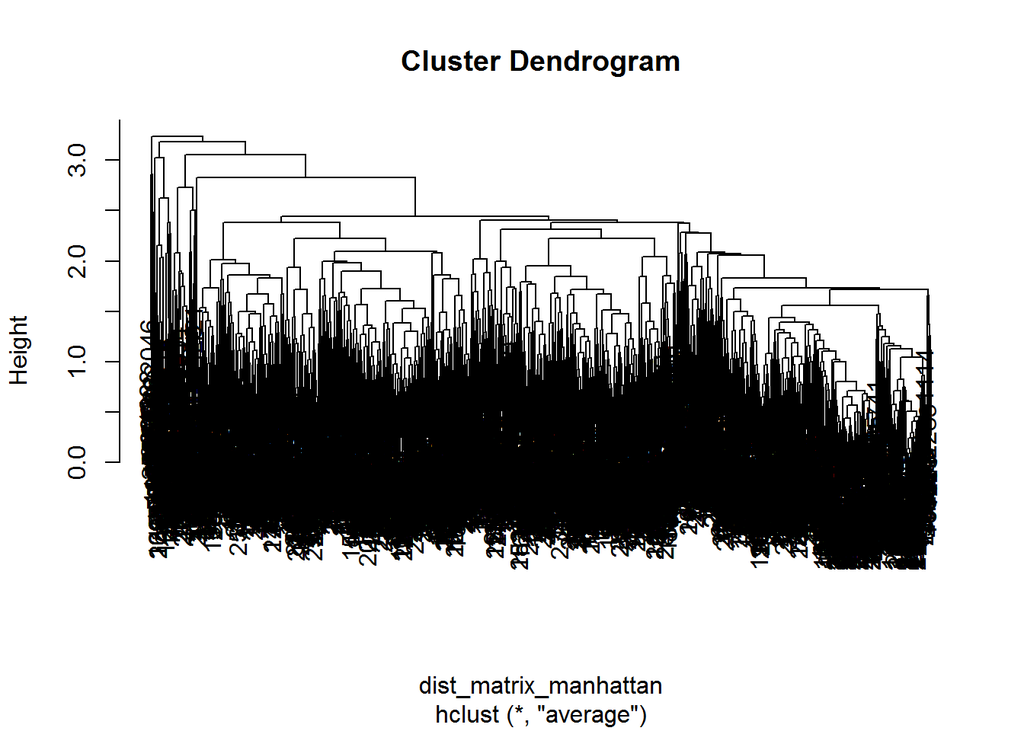

```r
plot(hier_clust_manhattan_average)
```

4. Now we need to choose the optimal number of clusters  
   To help us do this we use the package NbClust. This package looks at ~ 20 different indices to help make this decision. Since wards was the most interpretable, We will calculate all the different indices on this method.

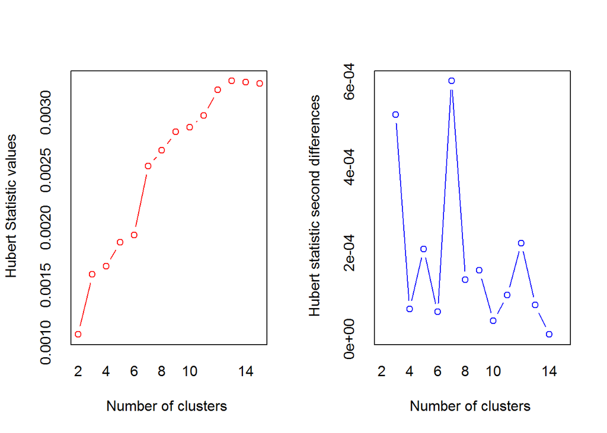

```
## *** : The Hubert index is a graphical method of determining the number of clusters.
##                 In the plot of Hubert index, we seek a significant knee that corresponds to a
##                 significant increase of the value of the measure i.e the significant peak in Hubert
##                 index second differences plot.
##
```

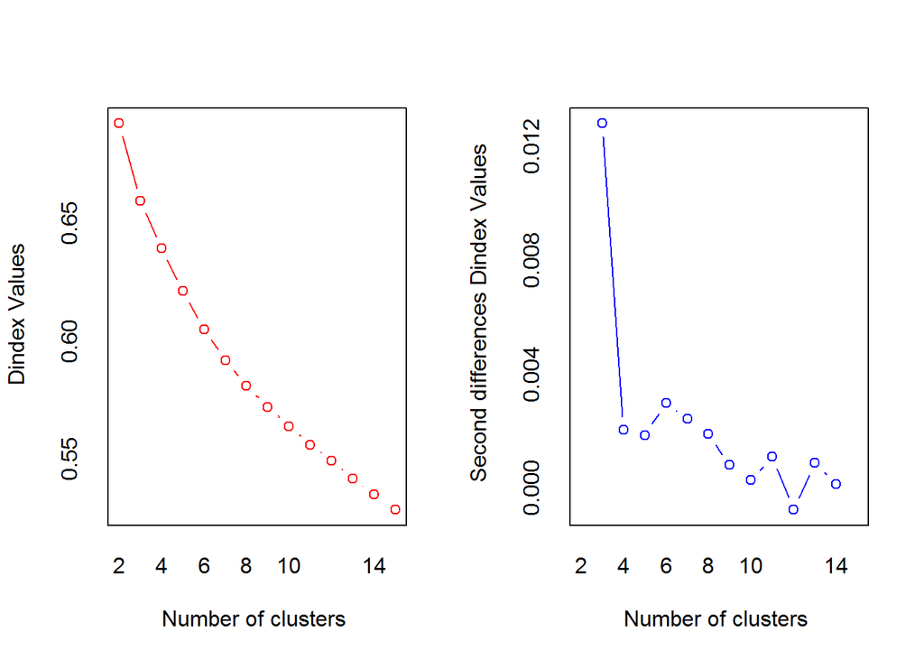

```
## *** : The D index is a graphical method of determining the number of clusters.
##                 In the plot of D index, we seek a significant knee (the significant peak in Dindex
##                 second differences plot) that corresponds to a significant increase of the value of
##                 the measure.
##
## * Among all indices:
## * 4 proposed 2 as the best number of clusters
## * 9 proposed 3 as the best number of clusters
## * 1 proposed 4 as the best number of clusters
## * 2 proposed 5 as the best number of clusters
## * 2 proposed 6 as the best number of clusters
## * 3 proposed 7 as the best number of clusters
## * 2 proposed 15 as the best number of clusters
##
##                    ***** Conclusion *****
##
## * According to the majority rule, the best number of clusters is  3
##
##
```

```r
clust_euclidean_ward <- NbClust(norm_df, distance = 'euclidean', method = 'ward.D')
```

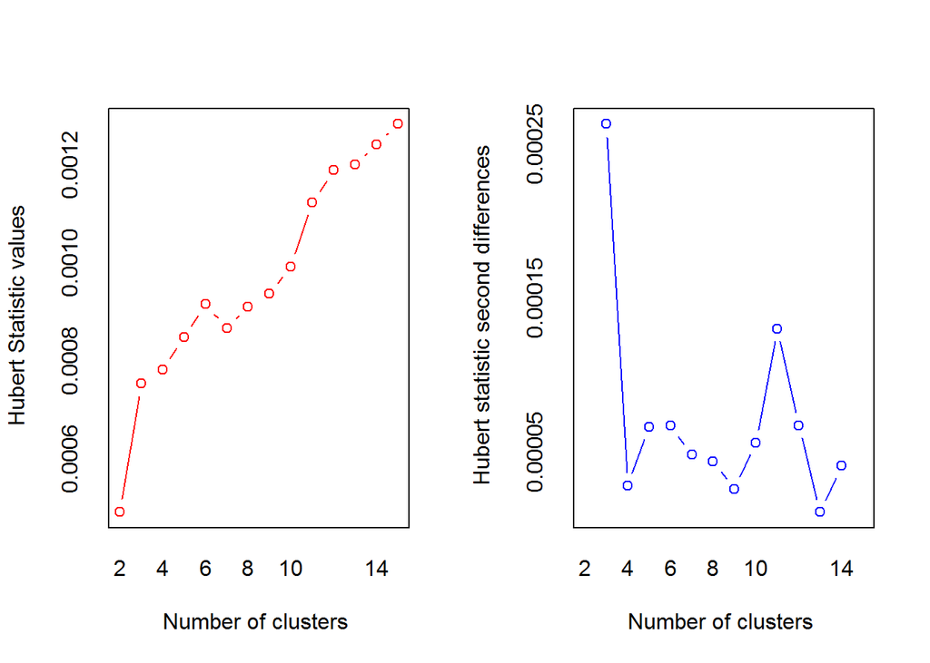

```
## *** : The Hubert index is a graphical method of determining the number of clusters.
##                 In the plot of Hubert index, we seek a significant knee that corresponds to a
##                 significant increase of the value of the measure i.e the significant peak in Hubert
##                 index second differences plot.
##
```

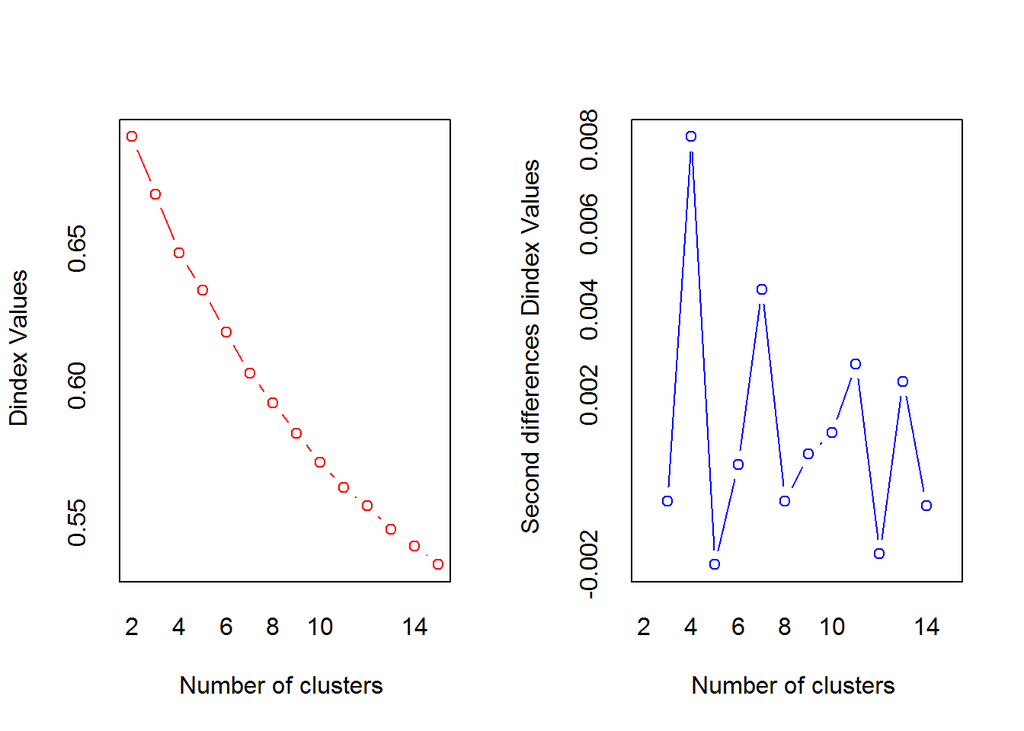

```
## *** : The D index is a graphical method of determining the number of clusters.
##                 In the plot of D index, we seek a significant knee (the significant peak in Dindex
##                 second differences plot) that corresponds to a significant increase of the value of
##                 the measure.
##
## * Among all indices:
## * 7 proposed 2 as the best number of clusters
## * 2 proposed 3 as the best number of clusters
## * 5 proposed 4 as the best number of clusters
## * 2 proposed 5 as the best number of clusters
## * 1 proposed 6 as the best number of clusters
## * 2 proposed 11 as the best number of clusters
## * 1 proposed 13 as the best number of clusters
## * 3 proposed 15 as the best number of clusters
##
##                    ***** Conclusion *****
##
## * According to the majority rule, the best number of clusters is  2
##
##
```

```r
clust_manhattan_ward <- NbClust(norm_df, distance = 'manhattan', method = 'ward.D')
```

The number of clusters from manhattan-ward was 2 and for euclidean-ward 3. Since we want to Help the marketer develop production types we will start at 3 and see attributes associated with each.

```r
clusters <- cutree(hier_clust_euclid_ward, k = 3)
df$clusters <- clusters


df %>%
  group_by(clusters) %>%
  mutate(n = n()) %>%
  summarise_each(funs(mean), -cnty) ->  df_summary

data.frame(df_summary)
```

```
##   clusters attitude planning  parents  goodval    getto      age     educ
## 1        1 5.945492 6.064706 5.535294 4.502353 5.072941 6.155294 5.530588
## 2        2 4.731063 4.351515 4.159307 3.567965 4.477056 7.233766 4.581818
## 3        3 5.059471 6.115903 4.535040 2.460916 2.787062 6.202156 5.545822
##     income    n
## 1 5.156471  850
## 2 3.818182 1155
## 3 6.664420  742
```

It is hard to glean much useful information from these 3 clusters. We move to 5 clusters for this reason

```r
clusters <- cutree(hier_clust_euclid_ward, k = 5)
df$clusters <- clusters


df %>%
  group_by(clusters) %>%
  mutate(n = n()) %>%
  summarise_each(funs(mean), -cnty) ->  df_summary

data.frame(df_summary)
```

```
##   clusters attitude planning  parents  goodval    getto      age     educ
## 1        1 5.786235 5.878543 6.014170 3.487854 5.414980 4.791498 5.645749
## 2        2 4.731063 4.351515 4.159307 3.567965 4.477056 7.233766 4.581818
## 3        3 5.214959 6.433249 4.420655 1.964736 2.158690 6.249370 5.100756
## 4        4 6.166484 6.323034 4.870787 5.910112 4.598315 8.047753 5.370787
## 5        5 4.880548 5.750725 4.666667 3.031884 3.510145 6.147826 6.057971
##     income    n
## 1 4.755061  494
## 2 3.818182 1155
## 3 3.979849  397
## 4 5.713483  356
## 5 9.753623  345
```

These clusters are much more defined and we can now make some marketing suggestions.